# HW4

Meng Cheng

11/23/2019

##Import required package

```r
rm(list = ls(all = TRUE))
library(igraph)
library(Matrix)
library(gdata)
library(proxy)
library(plm)
library(ggplot2)
library(data.table)
library(dplyr)
library(zoo)
```

##Import dataset and pre clean the data to include only US data

```r
#import dataset
data1 <- fread("box_office_revenues.csv", header = TRUE)
data2 <- fread("film_cast_members.csv", header = TRUE)
data3 <- fread("film_keywords.csv", header = TRUE)
data4 <- fread("producers_and_films.csv", header = TRUE)
data5 <- fread("production_subsidiaries.csv", header = TRUE)

#only consider US
data4 <- data4[data4$country=="us"]
#clean duplicate
data4 <- unique(data4)
```

#Question 1

1. First,we want to know if film makers that engage in collaborations with one another are more innovative or not. We can measure innovation through the number of new, never-before-seen keywords that are used in a film. We can also measure innovation through the number of new combinations of existing keywords that are used in a film. To account for the natural time cycle of the production process, consider a keyword or combination to be new if it has been introduced within the last three years. We also want to know what kinds of collaborations contribute to innovation: are collaborations between large, generalist production companies more innovative? Or, are collaborations between large producers and more specialized, smaller producers more innovative? For this first question, consider two different measures of identifying whether a firm is a generalist or not. Base one measure on the scale of a company’s productions: consider a production company to be a generalist if it is in the top quartile of the number of films released by producers that year. In general, a producer will be classified as a generalist if it makes more than one film in a year. Base the second measure on a company’s global coreness in the collaboration network: consider a production company to be a generalist if it is in the top quartile of coreness(eigenvector centrality) over its last ten observations. If a company has fewer than ten observations, treat the non-existent observations as zeros.
1. Classify each film by the type of collaboration that it represents. There should be five types for each measure of generalism:
1. Peripheral solo productions: films made by a single specialist
2. Central solo productions: films made by a single generalist
3. Central co-productions: films made by a group of multiple generalists
4. Peripheral co-productions: films made by a group of multiple specialists
5. Hybrid co-productions: films made by a group of generalists and specialists For each measure of generalism, a figure that illustrates the number of new keywords and new combinations of existing keywords that are introduced per type of film over the course of the data. On the x-axis should be years, and on the y-axis should be the count of new keywords or new combinations.

##Identify producer as generalist or specialist

###Measure 1

Base one measure on the scale of a company’s productions: consider a production company to be a generalist if it is in the top quartile of the number of films released by producers that year. In general, a producer will be classified as a generalist if it makes more than one film in a year.

```r
#create prolist to get the count - how many films produced by a producer each year
prodlist <- data4 %>%
  group_by(pcindex,year) %>%
  summarise(count = n())

#producer with more than 1 film produced in a year as Generalist, the opposite as Specialist
prodlist$type1 <- "S"
prodlist$type1[which(prodlist$count>1)] <- "G"
```

###Measure 2

Base the second measure on a company’s global coreness in the collaboration network: consider a production company to be a generalist if it is in the top quartile of coreness(eigenvector centrality) over its last ten observations. If a company has fewer than ten observations, treat the non-existent observations as zeros.

```r
#get the list of unique film information and unique producer information for future reference
uniquefilm <- data4[,1:2]
uniquefilm <- unique(uniquefilm)
uniqueprod <- unique(data4$pcindex)

#get the count of how many producer engaged in the production for each film
filmlist <- data4 %>%
  group_by(pindex,year) %>%
  summarise(count = n())

#since the max of count in filmlist is 11, which means at maximum there are 11 producers produce a film together
#so construct a matrix with nrow=13 would be enough to hold the corporation producer pcindex, the film pindex, year
#ncol is the number of films we have according to uniquefilm
cooplist <- matrix(nrow=13,ncol=14133)

#add pcindex, pindex and year information by column (each observation takes a column)
for (i in 1:dim(uniquefilm)[1]){
  film <- uniquefilm[i]$pindex
  year <- uniquefilm[i]$year
  prod <- data4$pcindex[which(data4$pindex==film)]
  cooplist[2:(length(prod)+1),i]<-prod
  cooplist[13,i]<-film
  cooplist[1,i]<-year
}

#get a corporation without film pindex in order to get possible_pairs in the next step
cooplistc <- cooplist[1:12,]

# take assignment 3 code as reference
# possible_pairs = lapply(seq_len(nrow(investors)), function(i) t(cooplistc[i,]))
# helpful to avoid vectoring on rows with apply functions when possible
# get all pairs
possible_pairs = lapply(seq_len(ncol(cooplistc)), function(i) cooplistc[,i])

# get rid of blanks to make the object smaller
for(i in seq_along(possible_pairs)){
    possible_pairs[[i]] = possible_pairs[[i]][!is.na(possible_pairs[[i]])]
}

# ignore films where there is only one producer
# can use logical index as in outlook email network setup
index = sapply(seq_along(possible_pairs), function(i) length(possible_pairs[[i]]) > 2)
possible_pairs = possible_pairs[index]

#get whole edgelist
edges = lapply(seq_along(possible_pairs), function(i) data.table(t(combn(possible_pairs[[i]][-1], 2)), year = possible_pairs[[i]][1] ))

# calling data table on this just so we can refer to column names and make the rest of the code more interpetable
# main issue is that it's not possible to call $ on matrix-type objects, even if they have explicit column names
edges = rbindlist(edges)

#change column name
colnames(edges) = c("v1", "v2", "year")

#get unique and ordered year list for future reference
yearlist <- as.integer(sort(unique(edges$year)))

#new data table to store all eigenvector centrality result
wholeresult <- data.table()

#for each year, calculate the eigenvector centralities for each company
for(selyear in yearlist){
  edge<- edges[edges$year<=selyear]
  network <- graph.data.frame(edge[,1:2],directed = FALSE)
  # get eigenvector centralities to measure global coreness
  eigencen <- eigen_centrality(network, directed = FALSE, scale = TRUE, weights = NULL, options = arpack_defaults)
  eigencent <- eigencen$vector
  namecol <- names(eigencent)
  eigencentcol <- unname(eigencent)
  result <- cbind(namecol,eigencentcol,selyear)
  colnames(result) = c("pcindex", "eigencen", "year")
  wholeresult <- rbind(wholeresult,result)
}

#add eigenvector centralities variable
prodlist <- merge(prodlist,wholeresult,by=c("pcindex","year"),all.x = TRUE)

#replace NA as 0, here NA stands for no corporation ever before
prodlist$eigencen[is.na(prodlist$eigencen)] <- 0

#calculate if a producer is a generalist as if it is in the top quartile of coreness(eigenvector centrality) over its last ten observations.

#to have a look on how many producer have more than 10 observation and how many dont
te <- prodlist %>%
  group_by(pcindex) %>%
  summarise(count = n())

#Suggestion from prof:
#For the prior average, this can be set up like the lags are set up in the solutions from Question 1A of Exercise 3, using the function rollapplyr() from the zoo package, grouping by production company on the sorted data table where each row represents a producer's coreness in a year that it makes a film. In this rollapplyr, the width would be (-10:1) instead of (-1).

#code reference:
#districts_adjrain[, (lags) := lapply(.SD, function(x) rollapplyr(x, list(-1), mean, partial = TRUE, fill = NA)), .SDcols = cols, by = district]
# can also do this in four lines, but cols/sdcols/lapply from the data table example saves a bit of space
# it's also a bit more modular in case we want to add columns in later on

#try
#cols_chosen <- c("eigencen")
#prodlist1[, lapply(.SD, function(x) rollapplyr(x,list(-10:1), mean, partial = TRUE, fill = NA)), .SDcols =cols_chosen, by = pcindex]

#not work, use the below method

#order the prolist by pcindex and year
setorderv(prodlist, c("pcindex", "year"))

#create new column to store rop quantile value for each film each year
prodlist$eigencen10 <- NA

#calculate the top quantile value
for(i in 1:dim(prodlist)[1]){
  prod<- prodlist[i,]$pcindex
  selyear <- prodlist[i,]$year
  obser <- prodlist[which(prodlist$pcindex==prod&prodlist$year<=selyear),]
  obser10 <- top_n(obser, 10, year)
  add <- 10-dim(obser10)[1]
  cal <- rep(0,times=add)
  cal <- as.numeric(c(cal,obser10$eigencen))
  prodlist[i,6]<-quantile(cal,c(0.75))
}

#make the judgement
prodlist$type2 <- "S"
prodlist$type2[which(prodlist$eigencen10<prodlist$eigencen)] <- "G"
```

##Identify film type

```r
#prepare the data, add producer type information
adjdata4 <- merge(data4, prodlist, by = c("pcindex","year"), all.x = TRUE,
      sort = TRUE, suffixes = c(".x",".y"), no.dups = TRUE)
```

###With Measure 1

```r
#make the judgement with measure 1 for film type
filmlist$typeM1<-0
for(i in 1:dim(filmlist)[1]){
  filmname <- filmlist[i,]$pindex
  prod <- adjdata4[adjdata4$pindex==filmname]
  if(filmlist[i,]$count==1){
    if(prod$type1 == "S"){
      type <- 1
      }
    else{
      type <- 2
      }}
  else if("S" %in% prod$type1){
    if("G" %in% prod$type1){
      type <- 5
      }
    else{
      type <- 4
    }
    }
  else{
    type <- 3
  }
  filmlist[i,4]<-type
}
```

###With Measure 2

```r
#make the judgement with measure 2 for film type
filmlist$typeM2<-0
for(i in 1:dim(filmlist)[1]){
  filmname <- filmlist[i,]$pindex
  prod <- adjdata4[adjdata4$pindex==filmname]
  if(filmlist[i,]$count==1){
    if(prod$type2 == "S"){
      type <- 1
      }
    else{
      type <- 2
      }}
  else if("S" %in% prod$type2){
    if("G" %in% prod$type2){
      type <- 5
      }
    else{
      type <- 4
    }
    }
  else{
    type <- 3
  }
  filmlist[i,5]<-type
}
```

##Indentify New

###New Single Keywords

```r
#combine the keyword information on film with year(add year information)
data3 <- merge(data3,filmlist,by="pindex",all.x = TRUE)
data3 <- data3[,1:3]

#clean missing data
data3 <- na.omit(data3)
```

```r
#find the first year that a keyword appears for each keyword
keywordlist <- data3 %>%
  group_by(keyword) %>%
  summarise(first=min(year))

#add the first appearence information
data3 <- merge(data3,keywordlist,by="keyword",all.x = TRUE)

#make the judgement if a keyword first shows up in last 3 year - a new keyword
data3$new <- data3$year<=(data3$first+3)

# original method which takes so long

#for(i in 1:dim(data3)[1]){
#  selkeyword <- data3[i]$keyword
#  selyear <- data3[i]$year
#  data3[i,4] <- as.logical(nrow(data3[which(data3$keyword==selkeyword&data3$year<(selyear-3)),])>0)
#  }
```

```r
#transer the logical variable to 0/1 variable
data3$newkey <- 0
data3$newkey[which(data3$new==TRUE)] <- 1

#use groupby to count of new keyword by film
newwordlist <- data3 %>%
  group_by(pindex) %>%
  summarise(newkeycount = sum(newkey))
```

###New Keywords Combination

```r
#new dataset for only existing kewword, for future reference as we only consider existing keyword for new combination
data3Exist <- data3[which(data3$newkey==0)]

#see how many existing keyword each film has
FilmWithMul <- data3Exist %>%
  group_by(pindex) %>%
  summarise(count = n())

#see how many films have more than 2 existing keywords, which is available for combination
FilmWithMul <- FilmWithMul[which(FilmWithMul$count>1),]
```

###get whole list of existing keyword combination

As this takes long time to run, here I just show the code I use.

When knit this rmd document, I import the saved result instead of rerunning this part of code.

Code Used:

```r
#setorderv(FilmWithMul,c("pindex"))
#setorderv(data3Exist,c("pindex"))

#wholecombinelist <-data.table()

#for(film in FilmWithMul$pindex){
#  newword <- data3Exist[which(data3Exist$pindex==film)]$keyword
#  com <- t(combn(newword,2))
#  combine <- cbind(film,com)
#  wholecombinelist <- rbind(wholecombinelist,combine)
#}

#write.csv(wholecombinelist, file = "wholecombinelist.csv")
```

```r
#read in saved result for above code and adjust format
wholecombinelist <- fread("wholecombinelist.csv", header = TRUE)
wholecombinelist <- wholecombinelist[,2:4]
```

```r
#set a new copy for further change
wholecombine <- wholecombinelist
names(wholecombine) <- c("pindex","W1","W2")
wholecombine$pindex <- as.integer(wholecombine$pindex)

#add year information
wholecombine <- merge(wholecombine,filmlist[,1:2],by="pindex",all.x=TRUE)

#to remove duplicate combination within a year but may appear in different film
#the combination data is by year but not by film now
wholecombineByY <- wholecombine[,2:4]
wholecombineByY <- unique(wholecombineByY)

#get the first year a combination appears and the freqence a combination appears
combineFq <- wholecombineByY %>%
  group_by(W1,W2) %>%
  summarise(count = n(),First=min(year))

#add first appearence and freqence information to the film level combination data
wholecombine <- merge(wholecombine,combineFq,by=c("W1","W2"),all.x = TRUE)
wholecombine$newcom <- (wholecombine$year-3 <= wholecombine$First)

#groupby pindex to get the count of new combination for each film
NewcombByfilm <- wholecombine %>%
  group_by(pindex) %>%
  summarise(newcom=sum(newcom))
```

##Clean and Format Final Result Data

```r
filmlistc <- merge(newwordlist,filmlist,by="pindex",all.y=TRUE)
filmlistclean <- na.omit(filmlistc)
filmlistclean <- merge(NewcombByfilm,filmlistclean,by="pindex",all.y=TRUE)
filmlistclean[is.na(filmlistclean)] <- 0
filmlistclean$typeM1 <-as.factor(filmlistclean$typeM1)
filmlistclean$typeM2 <-as.factor(filmlistclean$typeM2)
```

#A.Plot

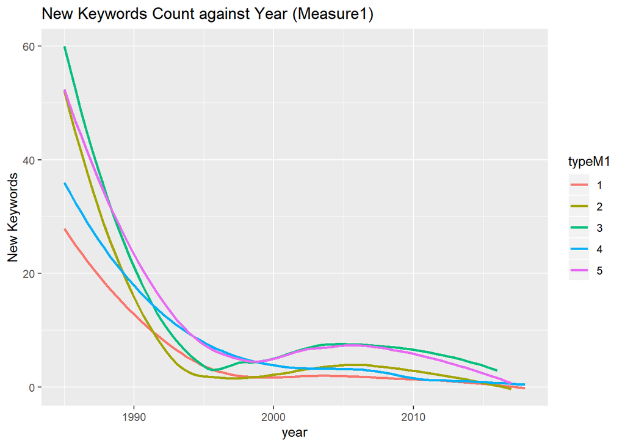

```r
Measure1Newkeyword <- ggplot(data = filmlistclean,aes(x = year, y = newkeycount)) +
  geom_smooth(method = "loess", se = F,mapping = aes(color = typeM1)) +
  labs(x = "year", y = "New Keywords",title="New Keywords Count against Year (Measure1)")

Measure1NewCom <- ggplot(data = filmlistclean,aes(x = year, y = newcom)) +
  geom_smooth(method = "loess", se = F,mapping = aes(color = typeM1)) +
  labs(x = "year", y = "New Combination",title="New Combination Count against Year (Measure1)")

Measure2Newkeyword <- ggplot(data = filmlistclean,aes(x = year, y = newkeycount)) +
  geom_smooth(method = "loess", se = F,mapping = aes(color = typeM2)) +
  labs(x = "year", y = "New Keywords",title="New Keywords Count against Year (Measure2)")

Measure2NewCom <- ggplot(data = filmlistclean,aes(x = year, y = newcom)) +
  geom_smooth(method = "loess", se = F,mapping = aes(color = typeM2)) +
  labs(x = "year", y = "New Combination",title="New Combination Count against Year (Measure2)")

Measure1Newkeyword
```

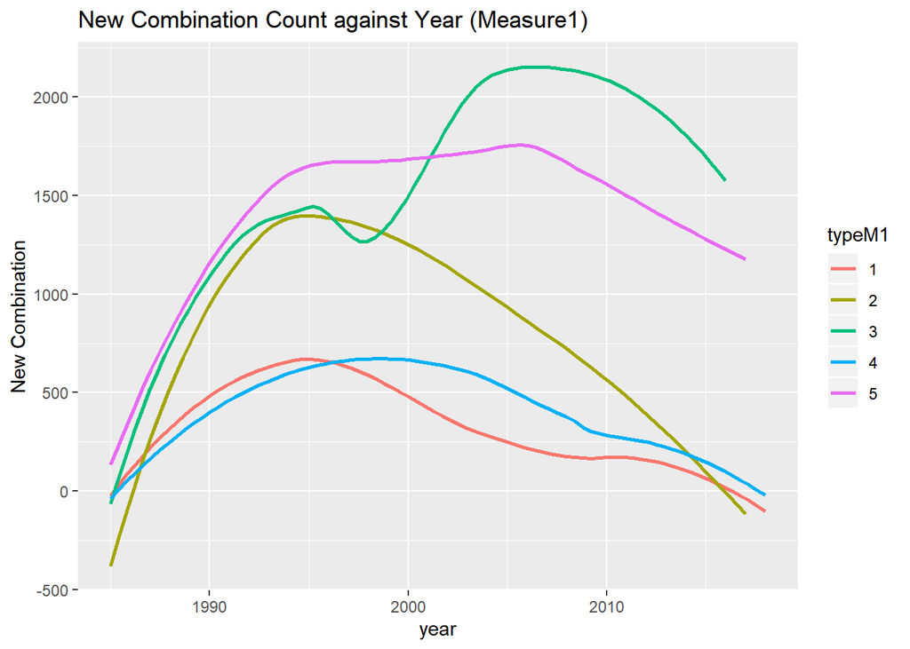

```r
Measure1NewCom
```

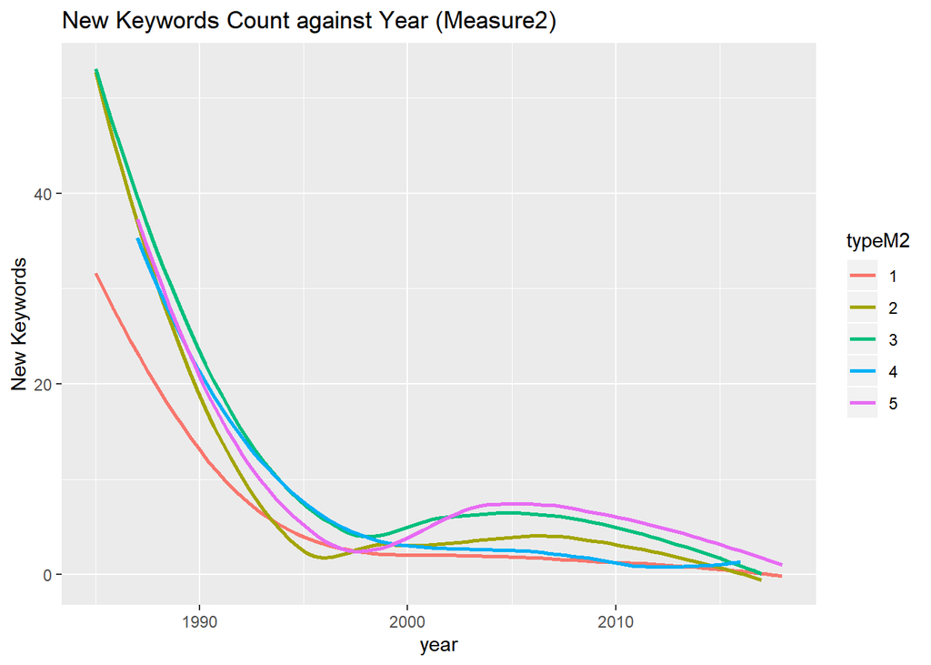

```r
Measure2Newkeyword
```

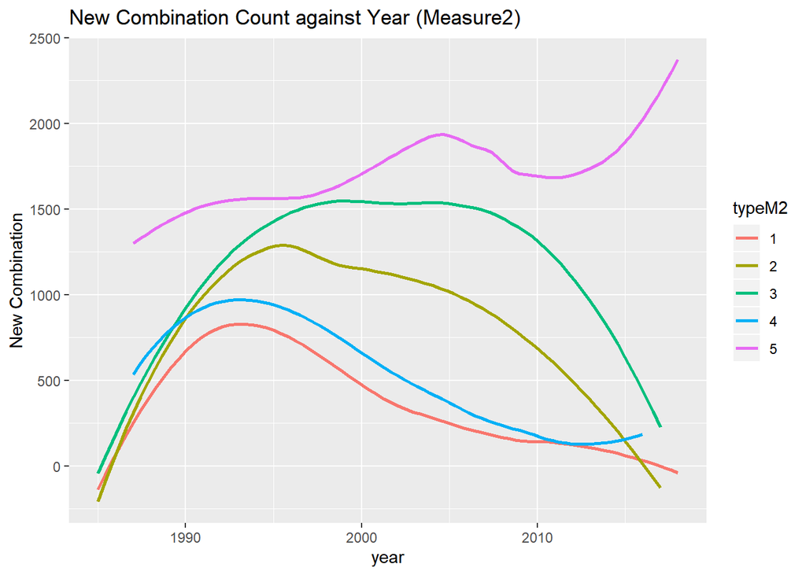

```r
Measure2NewCom
```

##INSIGHT

#B For each measure of generalism, estimate one regression predicting the number of new keywords and another regression predicting the number of new combinations of existing keywords producers introduce in a year. Use as predictors the number of films a producer makes that year that fall into each of the three co-production types. So, there will be three collaboration predictors

##Get Regression X variables

```r
data4clean <- adjdata4[,c(1:3,7,8,11)]
data4clean <- merge(data4clean,filmlistclean[,c(1:3,6,7)],by="pindex",all.x = TRUE)
data4clean <- na.omit(data4clean)
data4clean <- unique(data4clean)

#add box office information
data4clean <- merge(data4clean,data1[,c(1,4)],by="pindex",all.x = TRUE)
#exclude observations with box office data missing
data4clean <- data4clean[!is.na(data4clean$total_box),]
```

For the Jaccard distance, use as the input an incidence/affiliation matrix where on one dimension, e.g., rows, are the production companies and on the other, e.g., columns are the keywords used in each production companies films. To make the computation more memory efficient, you can use sparseMatrix() from the Matrix package – this applies to the incidence matrix mentioned above as well, and in general it makes sense to input the entries to these matrices as factors/numbers rather than characters.

##get coordinate data

```r
library(reshape2)
prodword <- merge(data3[,1:3],data4[,c(1,4)],by="pindex",allow.cartesian=TRUE)
prodwordc <- unique(prodword[,2:4])
```

As this takes long time to run, here I just show the code I use.

When knit this rmd document, I import the saved result instead of rerunning this part of code.

Code Used:

```r
#coorvar <- data.table()
#for(selyear in yearlist){
#  t1 <- prodwordc[which((prodwordc$year>=selyear-2)&(prodwordc$year<=selyear)),c(1,3)]
#  result <- data.frame(dcast(t1, pcindex ~ keyword,fun.aggregate=length), row.names = 1)
#  result[result>1] <- 1
#  t2 <- as.data.table(cmdscale(dist(result)),keep.rownames = TRUE)
#  t2$year <- selyear
#  coorvar <- rbind(coorvar,t2)
#}

#names(coorvar)<-c("pcindex","C1","C2","year")
#write.csv(coorvar, file = "coorvar.csv")
```

```r
#import saved result from above code and format
coorvar <- fread("coorvar.csv", header = TRUE)
coorvar <- coorvar[,2:5]
```

##Get Regression Data

```r
regvar <- data4clean %>%
  group_by(pcindex,year) %>%
  summarise(M1T3 = sum(typeM1==3),M1T4 = sum(typeM1==4),M1T5 = sum(typeM1==5),
            M2T3 = sum(typeM2==3),M2T4 = sum(typeM2==4),M2T5 = sum(typeM2==5),
            total_box = sum(total_box))
```

#Add by producer by year variables

```r
#add Coordinate 1 + Coordinate 2
regvar <- merge(regvar,coorvar,by=c("pcindex","year"),all.x = TRUE)

#get operation begin year
op <- data4clean %>%
  group_by(pcindex) %>%
  summarise(opyear = min(year))

#add operation year information
regvar <- merge(regvar,op,by="pcindex",all.x = TRUE)
regvar$opyears <- regvar$year - regvar$opyear

#get subsidary information
prodlist <- merge(prodlist,data5,by="pcindex",all.x=TRUE)
prodlist$sub <- 0

#check if there is producer that are still subsidary with no last_year, result is none
#t1<-prodlist[which(prodlist$first_year!=NA&prodlist$last_year==NA),]

prodlist$sub[which(prodlist$first_year<=year&prodlist$last_year>=year)]<-1

#add subsidary informtion
regvar <- merge(regvar,prodlist[,c(1,2,10)],by=c("pcindex","year"),all.x = TRUE)

#add offset - total films made that year, for which there is keyword information
numoffilm <- unique(data3[,c(1,3)]) %>%
  group_by(year) %>%
  summarise(NumFilm = n())

regvar <- merge(regvar,numoffilm,by=c("year"),all.x = TRUE)
```

#Y variable - producer level new keywords and new combination

```r
#new keyword
compNkw <- merge(data3[which(data3$newkey==1),],adjdata4[,c(1,3)],by="pindex",all.y=TRUE,allow.cartesian=TRUE)
compNkw <- unique(na.omit(compNkw)[,c(2,3,7)])

numofcompNkw <- compNkw %>%
  group_by(pcindex,year) %>%
  summarise(compNKw = n())

#new combination
compNC <- merge(wholecombine[which(wholecombine$newcom==TRUE),c(1:4,7)],adjdata4[,c(1,3)],by="pindex",all.y=TRUE,allow.cartesian=TRUE)
compNC <- unique(na.omit(compNC)[,c(2,3,4,6)])

numofcompNC <- compNC %>%
  group_by(pcindex,year) %>%
  summarise(compNC = n())

#add to regression data
regvar <- merge(regvar,numofcompNkw,by=c("pcindex","year"),all.x = TRUE)
regvar <- merge(regvar,numofcompNC,by=c("pcindex","year"),all.x = TRUE)

#replace NA with 0 - producer without new keywords or combination within the year
regvar$compNKw[is.na(regvar$compNKw)] <-0
regvar$compNC[is.na(regvar$compNC)] <-0
```

#Regression

```r
#make a copy
#write.csv(regvar, file = "regvar.csv")
#import and format again
regvar <- fread("regvar.csv", header = TRUE)
regvar <- regvar[,c(2:18)]
regvarc <- na.omit(regvar)
names(regvarc)[17] <- "compNc"


library(MASS)
#regression
regM1Newkw <- glm.nb(compNKw ~ M1T3 + M1T4 + M1T5 + C1 + C2 + total_box + opyears + sub + factor(year), data=regvarc, offset(NumFilm))

regM2Newkw <- glm.nb(compNKw ~ M2T3 + M2T4 + M2T5 + C1 + C2 + total_box + opyears + sub + factor(year), data=regvarc, offset(NumFilm))

#regM1NewC <- glm.nb(compNc ~ M1T3 + M1T4 + M1T5 + C1 + C2 + total_box + opyears + sub + factor(year), data=regvarc, offset(NumFilm))
#regM2NewC <- glm.nb(compNc ~ M2T3 + M2T4 + M2T5 + C1 + C2 + total_box + opyears + sub + factor(year), data=regvarc, offset(NumFilm))
#above 2 regressions get error 'step size truncated due to divergence.Error in glm.fitter(x = X, y = Y, w = w, etastart = eta, offset = offset,  : NA/NaN/Inf in 'x''

#try using glm(formula, data, offset, family = "poisson") as suggestted by prof
regM1NewC1 <- glm(compNc ~ M1T3 + M1T4 + M1T5 + C1 + C2 + total_box + opyears + sub + factor(year), data=regvarc, offset(NumFilm),family="poisson")

regM2NewC1 <- glm(compNc ~ M2T3 + M2T4 + M2T5 + C1 + C2 + total_box + opyears + sub + factor(year), data=regvarc, offset(NumFilm),family="poisson")

#show regression result
summary(regM1Newkw)
```

```
##
## Call:
## glm.nb(formula = compNKw ~ M1T3 + M1T4 + M1T5 + C1 + C2 + total_box +
##     opyears + sub + factor(year), data = regvarc, weights = offset(NumFilm),
##     init.theta = 1.280202244, link = log)
##
## Deviance Residuals:
##     Min       1Q   Median       3Q      Max
## -190.06   -62.83   -17.23    23.26   245.61
##
## Coefficients: (1 not defined because of singularities)
##                    Estimate Std. Error  z value Pr(>|z|)
## (Intercept)       4.251e+00  2.223e-03  1912.49   <2e-16 ***
## M1T3              2.121e-01  3.071e-04   690.57   <2e-16 ***
## M1T4             -2.457e-01  5.132e-04  -478.81   <2e-16 ***
## M1T5              2.344e-01  2.524e-04   928.57   <2e-16 ***
## C1                4.539e-02  4.158e-05  1091.60   <2e-16 ***
## C2                9.218e-03  7.536e-05   122.32   <2e-16 ***
## total_box         1.953e-09  2.215e-12   881.83   <2e-16 ***
## opyears           1.081e-02  3.273e-05   330.32   <2e-16 ***
## sub                      NA         NA       NA       NA
## factor(year)1986 -2.486e-01  2.912e-03   -85.36   <2e-16 ***
## factor(year)1987 -3.573e-01  2.924e-03  -122.20   <2e-16 ***
## factor(year)1988 -4.714e-01  2.826e-03  -166.82   <2e-16 ***
## factor(year)1989 -1.602e+00  2.860e-03  -560.21   <2e-16 ***
## factor(year)1990 -1.458e+00  2.917e-03  -499.93   <2e-16 ***
## factor(year)1991 -1.825e+00  3.042e-03  -599.97   <2e-16 ***
## factor(year)1992 -2.556e+00  3.142e-03  -813.52   <2e-16 ***
## factor(year)1993 -2.736e+00  3.014e-03  -907.61   <2e-16 ***
## factor(year)1994 -2.592e+00  2.860e-03  -906.36   <2e-16 ***
## factor(year)1995 -2.831e+00  2.723e-03 -1039.62   <2e-16 ***
## factor(year)1996 -2.978e+00  2.717e-03 -1096.16   <2e-16 ***
## factor(year)1997 -2.745e+00  2.660e-03 -1032.10   <2e-16 ***
## factor(year)1998 -2.850e+00  2.700e-03 -1055.80   <2e-16 ***
## factor(year)1999 -2.747e+00  2.607e-03 -1053.89   <2e-16 ***
## factor(year)2000 -2.653e+00  2.667e-03  -994.45   <2e-16 ***
## factor(year)2001 -2.884e+00  2.569e-03 -1122.93   <2e-16 ***
## factor(year)2002 -2.742e+00  2.506e-03 -1093.81   <2e-16 ***
## factor(year)2003 -2.749e+00  2.460e-03 -1117.31   <2e-16 ***
## factor(year)2004 -2.545e+00  2.386e-03 -1066.38   <2e-16 ***
```

[output cut: 13 more lines]

```
## Signif. codes:  0 '***' 0.001 '**' 0.01 '*' 0.05 '.' 0.1 ' ' 1
##
## (Dispersion parameter for Negative Binomial(1.2802) family taken to be 1)
##
##     Null deviance: 75599700  on 8096  degrees of freedom
## Residual deviance: 35939898  on 8058  degrees of freedom
## AIC: 181836483
##
## Number of Fisher Scoring iterations: 1
##
##
##               Theta:  1.280202
##           Std. Err.:  0.000433
##
##  2 x log-likelihood:  -181836402.964000
```

```r
summary(regM2Newkw)
```

```
##
## Call:
## glm.nb(formula = compNKw ~ M2T3 + M2T4 + M2T5 + C1 + C2 + total_box +
##     opyears + sub + factor(year), data = regvarc, weights = offset(NumFilm),
##     init.theta = 1.241747565, link = log)
##
## Deviance Residuals:
##     Min       1Q   Median       3Q      Max
## -197.93   -63.48   -16.64    22.93   256.23
##
## Coefficients: (1 not defined because of singularities)
##                    Estimate Std. Error  z value Pr(>|z|)
## (Intercept)       4.282e+00  2.258e-03  1896.11   <2e-16 ***
## M2T3              2.040e-01  2.173e-04   938.74   <2e-16 ***
## M2T4             -2.159e-01  8.075e-04  -267.36   <2e-16 ***
## M2T5              2.761e-01  2.768e-04   997.44   <2e-16 ***
## C1                4.985e-02  4.211e-05  1183.85   <2e-16 ***
## C2                1.271e-02  7.656e-05   165.96   <2e-16 ***
## total_box         2.210e-09  2.250e-12   982.04   <2e-16 ***
## opyears           1.233e-02  3.318e-05   371.56   <2e-16 ***
## sub                      NA         NA       NA       NA
## factor(year)1986 -2.331e-01  2.963e-03   -78.66   <2e-16 ***
## factor(year)1987 -2.810e-01  2.976e-03   -94.43   <2e-16 ***
## factor(year)1988 -4.515e-01  2.874e-03  -157.12   <2e-16 ***
## factor(year)1989 -1.700e+00  2.905e-03  -585.03   <2e-16 ***
## factor(year)1990 -1.450e+00  2.963e-03  -489.25   <2e-16 ***
## factor(year)1991 -1.812e+00  3.091e-03  -586.29   <2e-16 ***
## factor(year)1992 -2.597e+00  3.184e-03  -815.40   <2e-16 ***
## factor(year)1993 -2.819e+00  3.059e-03  -921.67   <2e-16 ***
## factor(year)1994 -2.698e+00  2.900e-03  -930.25   <2e-16 ***
## factor(year)1995 -2.922e+00  2.760e-03 -1058.95   <2e-16 ***
## factor(year)1996 -3.079e+00  2.755e-03 -1117.61   <2e-16 ***
## factor(year)1997 -2.795e+00  2.694e-03 -1037.59   <2e-16 ***
## factor(year)1998 -2.926e+00  2.736e-03 -1069.49   <2e-16 ***
## factor(year)1999 -2.856e+00  2.637e-03 -1083.04   <2e-16 ***
## factor(year)2000 -2.692e+00  2.699e-03  -997.33   <2e-16 ***
## factor(year)2001 -2.969e+00  2.601e-03 -1141.52   <2e-16 ***
## factor(year)2002 -2.860e+00  2.533e-03 -1129.24   <2e-16 ***
## factor(year)2003 -2.867e+00  2.484e-03 -1154.40   <2e-16 ***
## factor(year)2004 -2.605e+00  2.409e-03 -1081.46   <2e-16 ***
```

[output cut: 13 more lines]

```
## Signif. codes:  0 '***' 0.001 '**' 0.01 '*' 0.05 '.' 0.1 ' ' 1
##
## (Dispersion parameter for Negative Binomial(1.2417) family taken to be 1)
##
##     Null deviance: 73844845  on 8096  degrees of freedom
## Residual deviance: 35829558  on 8058  degrees of freedom
## AIC: 182429272
##
## Number of Fisher Scoring iterations: 1
##
##
##               Theta:  1.241748
##           Std. Err.:  0.000415
##
##  2 x log-likelihood:  -182429191.596000
```

```r
summary(regM1NewC1)
```

```
##
## Call:
## glm(formula = compNc ~ M1T3 + M1T4 + M1T5 + C1 + C2 + total_box +
##     opyears + sub + factor(year), family = "poisson", data = regvarc,
##     weights = offset(NumFilm))
##
## Deviance Residuals:
##      Min        1Q    Median        3Q       Max
## -19213.9   -2877.6   -1640.7     388.8   25552.8
##
## Coefficients: (1 not defined because of singularities)
##                    Estimate Std. Error    z value Pr(>|z|)
## (Intercept)      -9.571e+00  1.538e-01    -62.233   <2e-16 ***
## M1T3              1.503e-01  4.033e-06  37276.917   <2e-16 ***
## M1T4             -7.774e-01  1.555e-05 -49992.629   <2e-16 ***
## M1T5              1.089e-01  3.256e-06  33438.596   <2e-16 ***
## C1                2.495e-02  6.077e-07  41061.037   <2e-16 ***
## C2               -3.964e-03  1.073e-06  -3694.646   <2e-16 ***
## total_box         1.087e-09  2.448e-14  44382.726   <2e-16 ***
## opyears           2.288e-02  5.705e-07  40106.303   <2e-16 ***
## sub                      NA         NA         NA       NA
## factor(year)1986 -1.690e-02  1.975e-01     -0.086    0.932
## factor(year)1987 -1.102e-01  2.011e-01     -0.548    0.584
## factor(year)1988 -1.335e-01  1.939e-01     -0.688    0.491
## factor(year)1989  1.691e+01  1.538e-01    109.959   <2e-16 ***
## factor(year)1990  1.791e+01  1.538e-01    116.437   <2e-16 ***
## factor(year)1991  1.793e+01  1.538e-01    116.566   <2e-16 ***
## factor(year)1992  1.740e+01  1.538e-01    113.118   <2e-16 ***
## factor(year)1993  1.730e+01  1.538e-01    112.501   <2e-16 ***
## factor(year)1994  1.723e+01  1.538e-01    112.050   <2e-16 ***
## factor(year)1995  1.692e+01  1.538e-01    109.998   <2e-16 ***
## factor(year)1996  1.682e+01  1.538e-01    109.341   <2e-16 ***
## factor(year)1997  1.692e+01  1.538e-01    110.010   <2e-16 ***
## factor(year)1998  1.663e+01  1.538e-01    108.149   <2e-16 ***
## factor(year)1999  1.671e+01  1.538e-01    108.665   <2e-16 ***
## factor(year)2000  1.723e+01  1.538e-01    112.021   <2e-16 ***
## factor(year)2001  1.674e+01  1.538e-01    108.851   <2e-16 ***
## factor(year)2002  1.687e+01  1.538e-01    109.668   <2e-16 ***
## factor(year)2003  1.701e+01  1.538e-01    110.608   <2e-16 ***
## factor(year)2004  1.711e+01  1.538e-01    111.241   <2e-16 ***
## factor(year)2005  1.684e+01  1.538e-01    109.502   <2e-16 ***
## factor(year)2006  1.690e+01  1.538e-01    109.888   <2e-16 ***
## factor(year)2007  1.722e+01  1.538e-01    111.954   <2e-16 ***
## factor(year)2008  1.687e+01  1.538e-01    109.671   <2e-16 ***
## factor(year)2009  1.690e+01  1.538e-01    109.880   <2e-16 ***
## factor(year)2010  1.700e+01  1.538e-01    110.565   <2e-16 ***
## factor(year)2011  1.670e+01  1.538e-01    108.577   <2e-16 ***
## factor(year)2012  1.645e+01  1.538e-01    106.963   <2e-16 ***
## factor(year)2013  1.693e+01  1.538e-01    110.069   <2e-16 ***
## factor(year)2014  1.679e+01  1.538e-01    109.167   <2e-16 ***
## factor(year)2015  1.665e+01  1.538e-01    108.236   <2e-16 ***
## factor(year)2016  1.744e+01  1.538e-01    113.372   <2e-16 ***
## ---
## Signif. codes:  0 '***' 0.001 '**' 0.01 '*' 0.05 '.' 0.1 ' ' 1
##
## (Dispersion parameter for poisson family taken to be 1)
##
##     Null deviance: 1.5619e+11  on 8096  degrees of freedom
## Residual deviance: 9.1781e+10  on 8058  degrees of freedom
## AIC: 9.2006e+10
##
## Number of Fisher Scoring iterations: 7
```

```r
summary(regM2NewC1)
```

```
##
## Call:
## glm(formula = compNc ~ M2T3 + M2T4 + M2T5 + C1 + C2 + total_box +
##     opyears + sub + factor(year), family = "poisson", data = regvarc,
##     weights = offset(NumFilm))
##
## Deviance Residuals:
##      Min        1Q    Median        3Q       Max
## -19815.5   -3001.7   -1716.1     440.9   26028.3
##
## Coefficients: (1 not defined because of singularities)
##                    Estimate Std. Error    z value Pr(>|z|)
## (Intercept)      -8.560e+00  9.417e-02    -90.898   <2e-16 ***
## M2T3              9.691e-02  2.766e-06  35037.783   <2e-16 ***
## M2T4             -7.011e-01  1.966e-05 -35654.216   <2e-16 ***
## M2T5              1.355e-01  2.965e-06  45695.881   <2e-16 ***
## C1                2.523e-02  6.044e-07  41740.599   <2e-16 ***
## C2               -4.519e-03  1.075e-06  -4204.056   <2e-16 ***
## total_box         1.458e-09  2.558e-14  57000.170   <2e-16 ***
## opyears           2.662e-02  5.655e-07  47084.005   <2e-16 ***
## sub                      NA         NA         NA       NA
## factor(year)1986  1.015e-01  1.212e-01      0.837    0.403
## factor(year)1987  2.517e-02  1.223e-01      0.206    0.837
## factor(year)1988 -2.211e-02  1.183e-01     -0.187    0.852
## factor(year)1989  1.589e+01  9.417e-02    168.773   <2e-16 ***
## factor(year)1990  1.695e+01  9.417e-02    180.004   <2e-16 ***
## factor(year)1991  1.688e+01  9.417e-02    179.259   <2e-16 ***
## factor(year)1992  1.636e+01  9.417e-02    173.709   <2e-16 ***
## factor(year)1993  1.621e+01  9.417e-02    172.139   <2e-16 ***
## factor(year)1994  1.611e+01  9.417e-02    171.094   <2e-16 ***
## factor(year)1995  1.583e+01  9.417e-02    168.145   <2e-16 ***
## factor(year)1996  1.573e+01  9.417e-02    167.050   <2e-16 ***
## factor(year)1997  1.581e+01  9.417e-02    167.910   <2e-16 ***
## factor(year)1998  1.560e+01  9.417e-02    165.634   <2e-16 ***
## factor(year)1999  1.549e+01  9.417e-02    164.457   <2e-16 ***
## factor(year)2000  1.612e+01  9.417e-02    171.205   <2e-16 ***
## factor(year)2001  1.564e+01  9.417e-02    166.038   <2e-16 ***
## factor(year)2002  1.571e+01  9.417e-02    166.796   <2e-16 ***
## factor(year)2003  1.580e+01  9.417e-02    167.803   <2e-16 ***
## factor(year)2004  1.597e+01  9.417e-02    169.566   <2e-16 ***
## factor(year)2005  1.572e+01  9.417e-02    166.946   <2e-16 ***
## factor(year)2006  1.583e+01  9.417e-02    168.124   <2e-16 ***
## factor(year)2007  1.600e+01  9.417e-02    169.902   <2e-16 ***
## factor(year)2008  1.579e+01  9.417e-02    167.718   <2e-16 ***
## factor(year)2009  1.571e+01  9.417e-02    166.841   <2e-16 ***
## factor(year)2010  1.591e+01  9.417e-02    168.930   <2e-16 ***
## factor(year)2011  1.552e+01  9.417e-02    164.772   <2e-16 ***
## factor(year)2012  1.531e+01  9.417e-02    162.587   <2e-16 ***
## factor(year)2013  1.581e+01  9.417e-02    167.922   <2e-16 ***
## factor(year)2014  1.562e+01  9.417e-02    165.901   <2e-16 ***
## factor(year)2015  1.548e+01  9.417e-02    164.385   <2e-16 ***
## factor(year)2016  1.631e+01  9.417e-02    173.226   <2e-16 ***
## ---
## Signif. codes:  0 '***' 0.001 '**' 0.01 '*' 0.05 '.' 0.1 ' ' 1
##
## (Dispersion parameter for poisson family taken to be 1)
##
##     Null deviance: 1.5619e+11  on 8096  degrees of freedom
## Residual deviance: 9.3759e+10  on 8058  degrees of freedom
## AIC: 9.3984e+10
##
## Number of Fisher Scoring iterations: 6
```

##INSIGHT

What kinds of collaborations seem to result in the most new keywords and new combinations of existing keywords? Comparing the two measures of generalism, are collaborations between large or small companies or core and peripheral companies more effective for creative innovation?

-From the regression result, both Central co-production and Hybrid co-productions have positive effect on the new keywords and new combinations while Peripheral co-productions has negative effect on both no matter what measure of generalism we use. And all coefficients are highly significant according to p-value.

#Question 2

We can measure the extent to which a producer collaborates with similar producers as the average Jaccard distance between a producer and the other producers it works with based on the co-occurrence of keywords the producers use.

###Get the average Jaccard distance with similar method in question 1b

As this takes long time to run, here I just show the code I use.

When knit this rmd document, I import the saved result instead of rerunning this part of code.

Code Used:

```r
#avgDist <- data.table()
#for(selyear in yearlist){
#  t1 <- prodwordc[which((prodwordc$year>=selyear-2)&(prodwordc$year<=selyear)),c(1,3)]
#  result <- data.frame(dcast(t1, pcindex ~ keyword,fun.aggregate=length), row.names = 1)
#  result[result>1] <- 1
#  t2 <- apply(as.matrix(dist(result)), 1,mean,na.rm=TRUE)
#  t3 <- data.frame(names(t2),unname(t2))
#  t3$year <- selyear
#  avgDist <- rbind(avgDist,t3)
#}

#names(avgDist) <- c("pcindex","avgJD","year")
#write.csv(avgDist, file = "avgDist.csv")
```

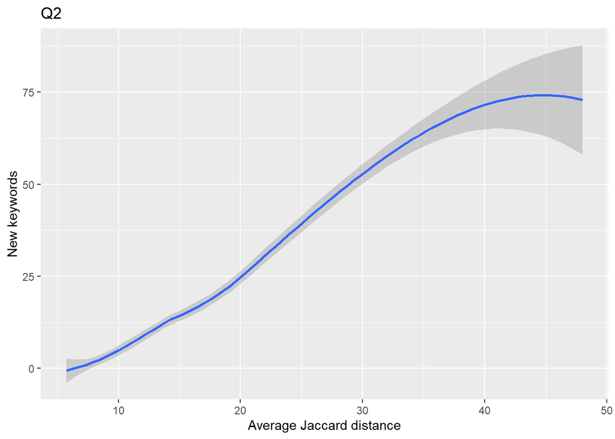

```r
#import saved data from above code
avgDist <- fread("avgDist.csv", header = TRUE)
regvarc1 <- merge(regvarc,avgDist,by=c("year","pcindex"),all.x=TRUE)

#plot
ggplot(regvarc1, aes(avgJD, compNKw)) +
  geom_smooth(method = "loess", se = T) +
  labs(x = "Average Jaccard distance", y = "New keywords",title = "Q2")
```

##INSIGHT

What does the pattern suggest about what kinds of collaborative partnerships might result in more creative innovation? Does this help to explain the results from Question 1?

From above plot, larger average Jaccard distance results in more creative innovation. Larger average Jaccard distance means that a producer has less common keywords in its films overall. This suggests that collaborative partnerships between varied producers could result in more creative innovation.

Respond to Question 1, it’s reasonable that for specialists, they are more small/peripheral in the film industry which means they have less common with other companies and may have their own special focus area (as the larger Jaccard distance). The opposite is true as well. The collaborative partnerships between this two type of producers(hybrid type) leads to more creative innovation.

#Question 3

Define each producer’s yearly return as its yearly box office revenue divided by the total release coverage it invested in for that year for its films.

```r
#get yearly return
data1<-merge(data1,adjdata4[,1:3],by=c("pindex"),all.x = TRUE)
data1c<-na.omit(data1[,c(1,2,4:6)])
Q3 <- data1c %>%
  group_by(pcindex,year) %>%
  summarise(total_box=sum(total_box),total_relcov=sum(release_coverage))
Q3$return <- Q3$total_box/Q3$total_relcov

#remove inf
Q3c <- Q3[!is.infinite(Q3$return),]
```

normalize each producer’s box office return compared to the returns that all producers earned that year. To do this, subtract the mean return of all producers for that year from a producer’s individual return and divide it by the standard deviation of the returns for all producers that year

```r
#since it's yearly
#get yearly std and mean
Q3yearly <- Q3c %>%
  group_by(year) %>%
  summarise(std=sd(return),mean=mean(return))

#get normalization
Q3c <- merge(Q3c,Q3yearly,by="year",all.x=TRUE)
Q3c$NReturn <- (Q3c$return-Q3c$mean)/Q3c$std

#add normalized returen to regression data
regvarc2 <- merge(regvarc1,Q3c[,c(1,2,8)],by=c("year","pcindex"),all.x=TRUE)
regvarc2 <- regvarc2[!is.na(regvarc2$NReturn),]

#regression
#could run correctly in rmd but when knit get error with help function
#paste the output result below
#Q31 <- lm(NReturn ??? M1T3 + M1T4 + M1T5 + C1 + C2 + total_box + opyears + sub + factor(year),data=regvarc2)

#Q32 <- lm(NReturn ??? M2T3 + M2T4 + M2T5 + C1 + C2 + total_box + opyears + sub + factor(year),data=regvarc2)

#summary(Q31)
#summary(Q32)
```

##output Call: lm(formula = NReturn ~ M1T3 + M1T4 + M1T5 + C1 + C2 + total_box + opyears + sub + factor(year), data = regvarc2)

Residuals: Min 1Q Median 3Q Max -4.4686 -0.4146 -0.1282 0.2236 19.6277

Coefficients: (1 not defined because of singularities) Estimate Std. Error t value Pr(>|t|)  
(Intercept) 3.162e-01 1.034e-01 3.059 0.00223 ** M1T3 -2.931e-01 1.591e-02 -18.425 < 2e-16 *M1T4 -4.021e-01 2.814e-02 -14.288 < 2e-16* M1T5 -3.467e-01 1.429e-02 -24.266 < 2e-16 C1 3.822e-03 2.224e-03 1.718 0.08576 .  
C2 4.669e-03 4.170e-03 1.120 0.26293  
total_box 5.898e-09 1.280e-10 46.074 < 2e-16 opyears 4.435e-03 1.871e-03 2.371 0.01776 *  
sub NA NA NA NA  
factor(year)1986 -1.007e-01 1.361e-01 -0.740 0.45962  
factor(year)1987 -1.732e-01 1.427e-01 -1.214 0.22497  
factor(year)1988 -8.431e-02 1.326e-01 -0.636 0.52500  
factor(year)1989 -2.201e-01 1.337e-01 -1.646 0.09981 .  
factor(year)1990 -2.755e-01 1.363e-01 -2.021 0.04328 *  
factor(year)1991 -3.928e-01 1.386e-01 -2.833 0.00462 ** factor(year)1992 -1.140e-01 1.351e-01 -0.844 0.39875  
factor(year)1993 -1.785e-01 1.368e-01 -1.304 0.19215  
factor(year)1994 -1.835e-01 1.294e-01 -1.418 0.15609  
factor(year)1995 -1.963e-01 1.262e-01 -1.556 0.11986  
factor(year)1996 -1.174e-01 1.239e-01 -0.948 0.34306  
factor(year)1997 -3.862e-01 1.239e-01 -3.117 0.00184 ** factor(year)1998 -2.072e-01 1.243e-01 -1.667 0.09557 .  
factor(year)1999 -2.666e-01 1.210e-01 -2.204 0.02757 *  
factor(year)2000 -3.048e-01 1.225e-01 -2.488 0.01288 *  
factor(year)2001 -2.089e-01 1.195e-01 -1.748 0.08048 .  
factor(year)2002 -2.137e-01 1.182e-01 -1.807 0.07073 .  
factor(year)2003 -2.609e-01 1.169e-01 -2.233 0.02561 *  
factor(year)2004 -1.470e-01 1.136e-01 -1.294 0.19573  
factor(year)2005 -1.200e-01 1.116e-01 -1.075 0.28224  
factor(year)2006 -7.324e-02 1.107e-01 -0.661 0.50836  
factor(year)2007 -1.482e-01 1.102e-01 -1.345 0.17861  
factor(year)2008 -1.863e-01 1.120e-01 -1.664 0.09612 .  
factor(year)2009 -1.765e-01 1.106e-01 -1.596 0.11060  
factor(year)2010 -1.926e-01 1.116e-01 -1.725 0.08457 .  
factor(year)2011 -1.229e-01 1.110e-01 -1.107 0.26821  
factor(year)2012 -1.265e-01 1.111e-01 -1.138 0.25517  
factor(year)2013 -1.967e-01 1.106e-01 -1.778 0.07545 .  
factor(year)2014 -1.105e-01 1.121e-01 -0.986 0.32434  
factor(year)2015 -1.311e-01 1.139e-01 -1.150 0.25003  
factor(year)2016 -2.657e-01 1.153e-01 -2.305 0.02121 *

Residual standard error: 0.8733 on 7980 degrees of freedom Multiple R-squared: 0.2385, Adjusted R-squared: 0.2348 F-statistic: 65.76 on 38 and 7980 DF, p-value: < 2.2e-16

##INSIGHT

What do the results suggest about financial outcomes for collaborations?

-Among three types of collaborations, no matter what measure of generalist we based on, number of peripheral co-productions has the biggest negative influence and number of central co-productions has the relatively lightest negative influence.

-It suggests that collaborations’ negative effect on financial outcomes is more significant within specialists and less significant within generalists. This may due to generalists are more experienced in collaboratins and have more resources.

#Question 4

Collaborations can be financially risky because of the coordination required to integrate multiple producers’ experiences into a making new film. Do producers gain anything from these collaborations creatively or financially in the long term?

1. Estimate a regression predicting the count of new keywords introduced in a producer’s solo produced films in a year.

```r
#get y variable
Q4 <- merge(filmlistclean[,c(1,3,6,7)],adjdata4[,c(1:3)],by="pindex",all.y=TRUE)
Q4 <- na.omit(Q4)

#for measure 1
Q4M1 <- Q4[which(Q4$typeM1==1|Q4$typeM1==2),] %>%
  group_by(pcindex,year) %>%
  summarise(csoloNKM1 = sum(newkeycount))

#for measure 2
Q4M2 <- Q4[which(Q4$typeM2==1|Q4$typeM2==2),] %>%
  group_by(pcindex,year) %>%
  summarise(csoloNKM2 = sum(newkeycount))
```

Use as a predictor the cumulative number of new keywords a producer has introduced in all of its films through the current year that were made in “hybrid” collaborations.

```r
#for measure 1
cumNKM1 <- Q4[which(Q4$typeM1==5),] %>%
  group_by(pcindex,year) %>%
  summarise(newkeycount = sum(newkeycount))

#cumulative value
cumNKM1 <- cumNKM1 %>%
  group_by(pcindex) %>%
  arrange(year) %>%
  mutate(cumNKM1 = cumsum(newkeycount))

#for measure 2
cumNKM2 <- Q4[which(Q4$typeM2==5),] %>%
  group_by(pcindex,year) %>%
  summarise(newkeycount = sum(newkeycount))

#cumulative value
cumNKM2 <- cumNKM2 %>%
  group_by(pcindex) %>%
  arrange(year) %>%
  mutate(cumNKM2 = cumsum(newkeycount))
```

###combine regression data

```r
#add cumulative new keywords count
regvarc3 <- merge(regvarc2,cumNKM1[,c(1,2,4)],by=c("year","pcindex"),all.x=TRUE)
regvarc3 <- merge(regvarc3,cumNKM2[,c(1,2,4)],by=c("year","pcindex"),all.x=TRUE)
regvarc3$cumNKM1[is.na(regvarc3$cumNKM1)] <- 0
regvarc3$cumNKM2[is.na(regvarc3$cumNKM2)] <- 0

#add y variable - count of new keywords introduced in a producer's solo produced films
regvarc3 <- merge(regvarc3,Q4M1,by=c("year","pcindex"),all.x=TRUE)
regvarc3 <- merge(regvarc3,Q4M2,by=c("year","pcindex"),all.x=TRUE)
regvarc3$csoloNKM1[is.na(regvarc3$csoloNKM1)] <- 0
regvarc3$csoloNKM2[is.na(regvarc3$csoloNKM2)] <- 0
```

###Use the same set of controls as in Questions 1 and 2. The outcome is a count, so use glm.nb().

```r
#run regression
Q41 <- glm.nb(csoloNKM1 ~ cumNKM1 + C1 + C2 + total_box + opyears + sub + factor(year), data=regvarc3)
```

[output not shown]

```r
Q42 <- glm.nb(csoloNKM2 ~ cumNKM2 + C1 + C2 + total_box + opyears + sub + factor(year), data=regvarc3)
```

[output not shown]

```r
summary(Q41)
```

```
##
## Call:
## glm.nb(formula = csoloNKM1 ~ cumNKM1 + C1 + C2 + total_box +
##     opyears + sub + factor(year), data = regvarc3, init.theta = 0.04449937352,
##     link = log)
##
## Deviance Residuals:
##     Min       1Q   Median       3Q      Max
## -0.8662  -0.4859  -0.4311  -0.3664   2.8946
##
## Coefficients: (1 not defined because of singularities)
##                    Estimate Std. Error z value Pr(>|z|)
## (Intercept)       3.502e+00  5.471e-01   6.401 1.54e-10 ***
## cumNKM1           6.118e-04  4.633e-04   1.321 0.186660
## C1                7.999e-02  1.215e-02   6.584 4.57e-11 ***
## C2                1.750e-02  2.356e-02   0.743 0.457599
## total_box         1.004e-09  6.199e-10   1.620 0.105298
## opyears          -6.608e-03  1.202e-02  -0.550 0.582400
## sub                      NA         NA      NA       NA
## factor(year)1986 -6.248e-01  7.310e-01  -0.855 0.392676
## factor(year)1987 -1.348e-01  7.667e-01  -0.176 0.860418
## factor(year)1988 -5.838e-01  7.126e-01  -0.819 0.412673
## factor(year)1989 -1.693e+00  7.179e-01  -2.358 0.018355 *
## factor(year)1990 -1.423e+00  7.329e-01  -1.942 0.052174 .
## factor(year)1991 -1.844e+00  7.462e-01  -2.472 0.013446 *
## factor(year)1992 -2.396e+00  7.265e-01  -3.298 0.000973 ***
## factor(year)1993 -3.396e+00  7.419e-01  -4.577 4.71e-06 ***
## factor(year)1994 -3.397e+00  6.990e-01  -4.859 1.18e-06 ***
## factor(year)1995 -3.894e+00  6.846e-01  -5.689 1.28e-08 ***
## factor(year)1996 -3.658e+00  6.711e-01  -5.451 5.01e-08 ***
## factor(year)1997 -3.986e+00  6.708e-01  -5.942 2.82e-09 ***
## factor(year)1998 -4.524e+00  6.793e-01  -6.660 2.74e-11 ***
## factor(year)1999 -4.535e+00  6.572e-01  -6.900 5.19e-12 ***
## factor(year)2000 -3.869e+00  6.604e-01  -5.859 4.66e-09 ***
## factor(year)2001 -4.835e+00  6.548e-01  -7.384 1.53e-13 ***
## factor(year)2002 -4.768e+00  6.421e-01  -7.426 1.12e-13 ***
## factor(year)2003 -4.778e+00  6.325e-01  -7.553 4.24e-14 ***
## factor(year)2004 -4.144e+00  6.114e-01  -6.778 1.22e-11 ***
## factor(year)2005 -4.251e+00  5.997e-01  -7.090 1.34e-12 ***
## factor(year)2006 -4.701e+00  5.961e-01  -7.887 3.09e-15 ***
```

[output cut: 12 more lines]

```
##
## (Dispersion parameter for Negative Binomial(0.0454) family taken to be 1)
##
##     Null deviance: 3152.4  on 8018  degrees of freedom
## Residual deviance: 2014.5  on 7982  degrees of freedom
## AIC: 10396
##
## Number of Fisher Scoring iterations: 25
##
##
##               Theta:  0.04450
##           Std. Err.:  0.00200
## Warning while fitting theta: alternation limit reached
##
##  2 x log-likelihood:  -10319.75000
```

```r
summary(Q42)
```

```
##
## Call:
## glm.nb(formula = csoloNKM2 ~ cumNKM2 + C1 + C2 + total_box +
##     opyears + sub + factor(year), data = regvarc3, init.theta = 0.0453679449,
##     link = log)
##
## Deviance Residuals:
##     Min       1Q   Median       3Q      Max
## -0.8534  -0.4718  -0.4324  -0.3699   2.9693
##
## Coefficients: (1 not defined because of singularities)
##                    Estimate Std. Error z value Pr(>|z|)
## (Intercept)       3.777e+00  5.530e-01   6.830 8.49e-12 ***
## cumNKM2           1.501e-03  8.838e-04   1.698  0.08943 .
## C1                5.523e-03  1.258e-02   0.439  0.66062
## C2                1.556e-02  2.371e-02   0.656  0.51173
## total_box         3.223e-09  5.922e-10   5.443 5.25e-08 ***
## opyears          -9.315e-03  1.146e-02  -0.813  0.41645
## sub                      NA         NA      NA       NA
## factor(year)1986 -1.072e+00  7.385e-01  -1.452  0.14660
## factor(year)1987 -4.502e-01  7.748e-01  -0.581  0.56120
## factor(year)1988 -1.041e+00  7.202e-01  -1.446  0.14830
## factor(year)1989 -2.004e+00  7.254e-01  -2.763  0.00572 **
## factor(year)1990 -1.383e+00  7.412e-01  -1.866  0.06208 .
## factor(year)1991 -1.788e+00  7.547e-01  -2.369  0.01785 *
## factor(year)1992 -2.142e+00  7.354e-01  -2.913  0.00358 **
## factor(year)1993 -3.959e+00  7.479e-01  -5.293 1.20e-07 ***
## factor(year)1994 -3.978e+00  7.055e-01  -5.639 1.72e-08 ***
## factor(year)1995 -4.285e+00  6.892e-01  -6.217 5.05e-10 ***
## factor(year)1996 -4.260e+00  6.765e-01  -6.297 3.03e-10 ***
## factor(year)1997 -4.210e+00  6.766e-01  -6.223 4.89e-10 ***
## factor(year)1998 -4.938e+00  6.841e-01  -7.219 5.23e-13 ***
## factor(year)1999 -4.955e+00  6.626e-01  -7.478 7.53e-14 ***
## factor(year)2000 -3.927e+00  6.694e-01  -5.866 4.45e-09 ***
## factor(year)2001 -5.292e+00  6.577e-01  -8.046 8.53e-16 ***
## factor(year)2002 -5.105e+00  6.483e-01  -7.874 3.42e-15 ***
## factor(year)2003 -5.019e+00  6.390e-01  -7.855 4.00e-15 ***
## factor(year)2004 -4.662e+00  6.170e-01  -7.555 4.20e-14 ***
## factor(year)2005 -4.579e+00  6.054e-01  -7.562 3.96e-14 ***
## factor(year)2006 -4.971e+00  6.019e-01  -8.260  < 2e-16 ***
```

[output cut: 12 more lines]

```
##
## (Dispersion parameter for Negative Binomial(0.0445) family taken to be 1)
##
##     Null deviance: 3102.5  on 8018  degrees of freedom
## Residual deviance: 2008.2  on 7982  degrees of freedom
## AIC: 10418
##
## Number of Fisher Scoring iterations: 25
##
##
##               Theta:  0.04537
##           Std. Err.:  0.00204
## Warning while fitting theta: alternation limit reached
##
##  2 x log-likelihood:  -10341.83200
```

##INSIGHT

Does creative innovation gained through collaborations make a producer’s solo-produced films more innovative? What does this suggest?

-Form above regression results, cumulative count of new keywords introdced in hybrid collaborations with both measures have positive but not significant effect on solo-produced films’ innovation.

-It suggests that producer indeed get creative innovation gained through collaborations onto solo=produced films’ innovation but the effect is slightly and could not be relied on.

2. Accounting for a producer’s engaging in collaborations, does introducing new keywords result in higher box office returns?

To gain insight into this, estimate the same regression model from Question 2, but add in a predictor for the number of new keywords introduced.

```r
#regression with one more predictor for the cumulative count of new keywords introduced
#could run correctly in rmd but when knit get error with help function
#paste the output result below
#Q4B1 <- lm(NReturn ???  cumNKM1 + M1T3 + M1T4 + M1T5 + C1 + C2 + total_box + opyears + sub + factor(year),data=regvarc3)
#Q4B2 <- lm(NReturn ???  cumNKM2 + M2T3 + M2T4 + M2T5 + C1 + C2 + total_box + opyears + sub + factor(year),data=regvarc3)

#summary(Q4B1)
#summary(Q4B2)
```

##result

Call: lm(formula = NReturn ~ cumNKM1 + M1T3 + M1T4 + M1T5 + C1 + C2 + total_box + opyears + sub + factor(year), data = regvarc3)

Residuals: Min 1Q Median 3Q Max -4.1789 -0.4147 -0.1334 0.2213 19.6332

Coefficients: (1 not defined because of singularities) Estimate Std. Error t value Pr(>|t|)  
(Intercept) 2.801e-01 1.028e-01 2.726 0.006430 ** cumNKM1 -9.111e-04 8.957e-05 -10.172 < 2e-16 *M1T3 -2.844e-01 1.583e-02 -17.972 < 2e-16* M1T4 -3.417e-01 2.858e-02 -11.957 < 2e-16 *M1T5 -2.874e-01 1.534e-02 -18.736 < 2e-16* C1 5.249e-03 2.214e-03 2.370 0.017791 *  
C2 3.695e-03 4.145e-03 0.891 0.372731  
total_box 6.219e-09 1.310e-10 47.455 < 2e-16 *opyears 1.283e-02 2.033e-03 6.308 2.98e-10* sub NA NA NA NA  
factor(year)1986 -8.511e-02 1.352e-01 -0.629 0.529161  
factor(year)1987 -1.291e-01 1.419e-01 -0.910 0.362737  
factor(year)1988 -5.643e-02 1.318e-01 -0.428 0.668602  
factor(year)1989 -1.977e-01 1.329e-01 -1.487 0.136938  
factor(year)1990 -2.545e-01 1.354e-01 -1.880 0.060196 .  
factor(year)1991 -3.863e-01 1.378e-01 -2.804 0.005064 ** factor(year)1992 -1.172e-01 1.343e-01 -0.873 0.382956  
factor(year)1993 -1.751e-01 1.360e-01 -1.288 0.197920  
factor(year)1994 -2.040e-01 1.286e-01 -1.587 0.112594  
factor(year)1995 -2.307e-01 1.254e-01 -1.839 0.065976 .  
factor(year)1996 -1.608e-01 1.231e-01 -1.306 0.191529  
factor(year)1997 -4.241e-01 1.232e-01 -3.443 0.000579 *factor(year)1998 -2.448e-01 1.236e-01 -1.981 0.047592*  
factor(year)1999 -3.062e-01 1.203e-01 -2.546 0.010917 *  
factor(year)2000 -3.436e-01 1.218e-01 -2.821 0.004798 factor(year)2001 -2.523e-01 1.188e-01 -2.123 0.033780 *  
factor(year)2002 -2.630e-01 1.176e-01 -2.237 0.025311 *  
factor(year)2003 -3.023e-01 1.162e-01 -2.601 0.009300 ** factor(year)2004 -1.809e-01 1.130e-01 -1.601 0.109384  
factor(year)2005 -1.540e-01 1.109e-01 -1.388 0.165098  
factor(year)2006 -1.093e-01 1.101e-01 -0.993 0.320925  
factor(year)2007 -1.899e-01 1.096e-01 -1.734 0.083045 .  
factor(year)2008 -2.212e-01 1.113e-01 -1.987 0.046942 *  
factor(year)2009 -2.214e-01 1.100e-01 -2.014 0.044084 *  
factor(year)2010 -2.364e-01 1.110e-01 -2.130 0.033201 *  
factor(year)2011 -1.617e-01 1.103e-01 -1.466 0.142801  
factor(year)2012 -1.676e-01 1.105e-01 -1.517 0.129310  
factor(year)2013 -2.402e-01 1.100e-01 -2.183 0.029066 *  
factor(year)2014 -1.562e-01 1.115e-01 -1.402 0.161092  
factor(year)2015 -1.744e-01 1.133e-01 -1.540 0.123709  
factor(year)2016 -3.171e-01 1.147e-01 -2.765 0.005704 ** — Signif. codes: 0 ‘**’ 0.001 ’**’ 0.01 ’’ 0.05 ‘.’ 0.1 ’ ’ 1

Residual standard error: 0.8672 on 7979 degrees of freedom Multiple R-squared: 0.2493, Adjusted R-squared: 0.2456 F-statistic: 67.94 on 39 and 7979 DF, p-value: < 2.2e-16

Call: lm(formula = NReturn ~ cumNKM2 + M2T3 + M2T4 + M2T5 + C1 + C2 + total_box + opyears + sub + factor(year), data = regvarc3)

Residuals: Min 1Q Median 3Q Max -4.1904 -0.4143 -0.1349 0.2222 19.6526

Coefficients: (1 not defined because of singularities) Estimate Std. Error t value Pr(>|t|)  
(Intercept) 3.141e-01 1.033e-01 3.039 0.002379 ** cumNKM2 -1.469e-03 1.941e-04 -7.565 4.30e-14 *M2T3 -3.246e-01 1.164e-02 -27.873 < 2e-16* M2T4 -3.234e-01 4.269e-02 -7.577 3.95e-14 *M2T5 -2.764e-01 1.672e-02 -16.529 < 2e-16* C1 4.117e-03 2.224e-03 1.851 0.064149 .  
C2 4.442e-03 4.164e-03 1.067 0.286140  
total_box 6.094e-09 1.294e-10 47.111 < 2e-16 *opyears 8.169e-03 1.914e-03 4.268 2.00e-05* sub NA NA NA NA  
factor(year)1986 -1.226e-01 1.361e-01 -0.901 0.367770  
factor(year)1987 -1.836e-01 1.427e-01 -1.286 0.198524  
factor(year)1988 -9.467e-02 1.326e-01 -0.714 0.475380  
factor(year)1989 -2.360e-01 1.336e-01 -1.767 0.077264 .  
factor(year)1990 -2.871e-01 1.362e-01 -2.108 0.035100 *  
factor(year)1991 -4.290e-01 1.391e-01 -3.085 0.002042 ** factor(year)1992 -1.414e-01 1.349e-01 -1.048 0.294507  
factor(year)1993 -1.904e-01 1.366e-01 -1.394 0.163334  
factor(year)1994 -2.225e-01 1.292e-01 -1.723 0.084972 .  
factor(year)1995 -2.448e-01 1.258e-01 -1.946 0.051709 .  
factor(year)1996 -1.658e-01 1.236e-01 -1.342 0.179625  
factor(year)1997 -4.281e-01 1.235e-01 -3.467 0.000529 *factor(year)1998 -2.571e-01 1.239e-01 -2.075 0.038002*  
factor(year)1999 -3.232e-01 1.203e-01 -2.687 0.007220 factor(year)2000 -3.605e-01 1.220e-01 -2.954 0.003142 ** factor(year)2001 -2.590e-01 1.190e-01 -2.177 0.029500 *  
factor(year)2002 -2.692e-01 1.174e-01 -2.293 0.021866 *  
factor(year)2003 -3.111e-01 1.160e-01 -2.683 0.007313 ** factor(year)2004 -2.001e-01 1.127e-01 -1.775 0.075908 .  
factor(year)2005 -1.675e-01 1.107e-01 -1.512 0.130500  
factor(year)2006 -1.266e-01 1.104e-01 -1.147 0.251554  
factor(year)2007 -2.098e-01 1.096e-01 -1.913 0.055723 .  
factor(year)2008 -2.323e-01 1.119e-01 -2.076 0.037928 *  
factor(year)2009 -2.363e-01 1.096e-01 -2.156 0.031126 *  
factor(year)2010 -2.477e-01 1.110e-01 -2.232 0.025644 *  
factor(year)2011 -1.679e-01 1.103e-01 -1.523 0.127896  
factor(year)2012 -1.835e-01 1.104e-01 -1.662 0.096524 .  
factor(year)2013 -2.543e-01 1.101e-01 -2.310 0.020938 *  
factor(year)2014 -1.656e-01 1.117e-01 -1.482 0.138317  
factor(year)2015 -1.861e-01 1.134e-01 -1.641 0.100887  
factor(year)2016 -3.197e-01 1.149e-01 -2.782 0.005407 ** — Signif. codes: 0 ‘**’ 0.001 ’**’ 0.01 ’’ 0.05 ‘.’ 0.1 ’ ’ 1

Residual standard error: 0.8703 on 7979 degrees of freedom Multiple R-squared: 0.2439, Adjusted R-squared: 0.2402 F-statistic: 65.99 on 39 and 7979 DF, p-value: < 2.2e-16

##INSIGHT

Does this result help explain why producers might engage in collaborations, eventhough they can be financially risky?

-From above regression results, the cumulative count of new keywords introduced with both measures has negative and significant effect on the financial return. It suggests that the direction of getting innovative and gainning higher financial return is opposite. And both coefficients are really small (-9.111e-04 and -1.469e-03).

-It does help explain why producers might engage in collaboration as they can be financially risky. They have this trade-off and have the choice to sacrifice a relatively small amount on financial return for more creative innovation.

#Extra Credit

We also have information about the people that work on films as cast members. These include actors, writers, directors, and other kinds of creative talent. The file “film_cast_members.csv” contains a unique key identifying the creative talent and describes what role they worked on as a member of the cast of each film. One way that production companies might benefit from collaborating with one another is that it helps them hire more innovative creative talent to work on their films.

###Define a cast member’s innovativeness as the cumulative number of new keywords created in the films that they have worked on in their career up to the prior year.

```r
#with merge function, inner join the film-new keyword information and data2(film_cast_member.csv).
ex1 <- merge(filmlistclean,data2,by=c("pindex","year"))
ex1 <- ex1[,c(1,2,4,9:12)]

#groupby cast member and year and get the sum of new keywords
ex2 <- ex1 %>%
  group_by(nconst,year) %>%
  summarise(newkeycount = sum(newkeycount))

#cumulative value
ex2 <- ex2 %>%
  group_by(nconst) %>%
  arrange(year) %>%
  mutate(cumNK = cumsum(newkeycount))
```

##Assumed Approach

###Using the scale-based classification to define generalists and specialists

1.merge the ex2(data table contain cast member innovativeness information) with film-producer data table to get the sum of innovativeness by pcindex by year

2.get the top 75% point value by year

3.make judgement if a producer is a generalist or specialist

4.categorize film based on this new measure of generalist

###Estimate a regression predicting the innovativeness of the hired creative talent based on the types of collaborations a production company engages in.

1.regression is like:

reg <- glm.nb(sum of innovativeness by producer by year ~ M3T3 + M3T4 + M3T5 + C1 + C2 + total_box + opyears + sub + factor(year), data=regvarc, offset(NumFilm))

###Does engaging in more hybrid collaborations seem to help with hiring more innovative creative talent?

I assume that from above regression, the coefficients of M3T3, M3T4, M3T5(number of three types of collaborations respectively) should be positive and significant. Among the three types of collaboration, M3T5(number of hybrid collaborations) should have the largest coefficient. It suggests that engaging in more hybrid collaborations seem to help with hiring more innocative creative talent.